# Exploring Spatial Data

Anna Vasylytsya

01/09/2020

```r
library(rgdal) # used here for reading and writing shapefiles
library(raster) # for reading, writing, and raster operation/manipulation
library(leaflet) # interactive maps of spatial data
library(tmap) # interactive maps of spatial data
```

```r
sa_cntries <- readOGR(paste0(proj_path, "/data/south_america_shp/SouthAmerica.shp"))
##sa_roads <- readOGR(paste0(proj_path, "/data/road_shp/GRIP4_region2.shp"))
# a rather large file, a lot of road segments
sa_roads <- readOGR(paste0(proj_path, "/data/road_shp/sa_highway_primary.shp"))
pop17 <- raster(paste0(proj_path, "/data/pop17_tif/ppp_2017_1km_Aggregated.tif"))
```

## base::plot

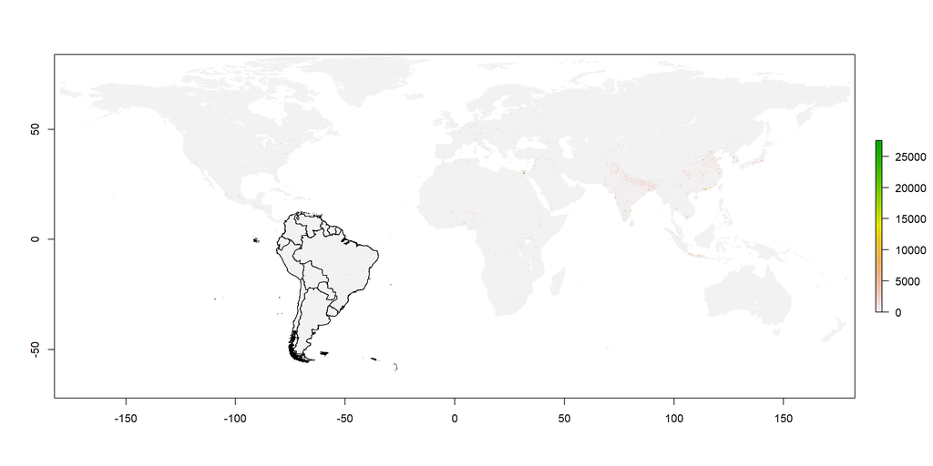

```r
plot(pop17)
plot(sa_cntries, add = TRUE)
```

As you noticed above, the population raster is of the whole world. We can crop it just to South America or a particular country. We need two functions from the raster package to do this 1) crop - which crops the extent (i.e. bounding box) and 2) mask - which crops to be shapefile boundary.

For this example, I will focus on Bolivia. First, we need to subset the countries shapefile to Bolivia.

```r
# the shapefile has a dataframe, so we subset just like we would a dataframe.
#View(sa_cntries@data)
bol <- sa_cntries[sa_cntries$Name == "BOLIVIA", ]
```

### Cropping and masking a raster file

Using the raster package, the crop function only crops the extent of the raster (in other words, the outer edges of the rectangle that can hold the Bolivia shapefile). Mask does what people normally call crop, which is only keep the parts of the raster that are within the boundary of the shapefile.

```r
bol_pop17 <- raster::crop(pop17, bol)
bol_pop17 <- raster::mask(bol_pop17, bol) # note: you are replacing the bol_pop17 object here!
```

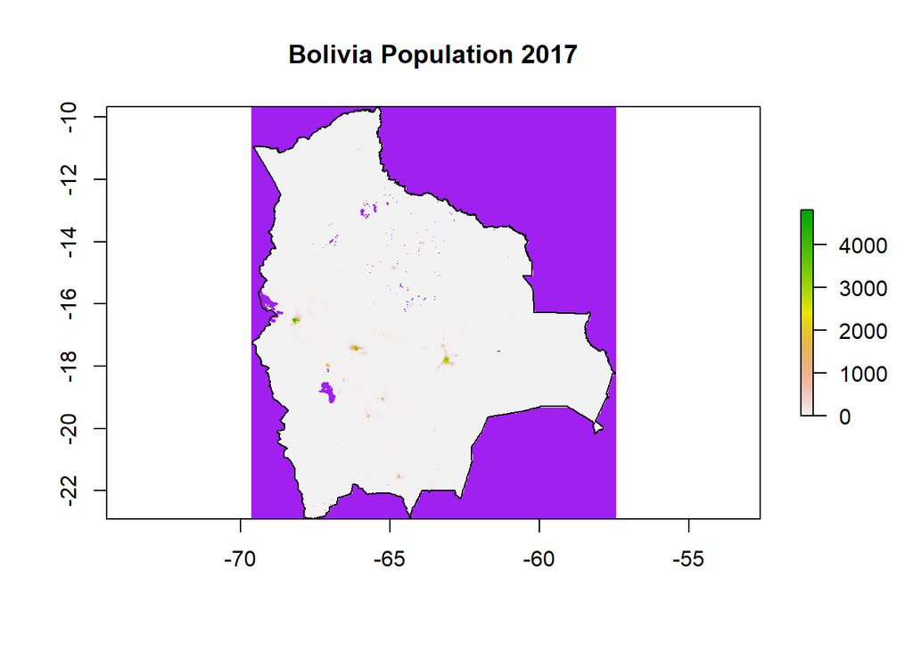

```r
plot(bol_pop17, colNA = "purple", main = "Bolivia Population 2017")
#color NA areas with purple, purple areas within Bolivia are likely waterbodies or parks
plot(bol, add = TRUE)
```

### Cropping a shapefile

We can also crop all of the road segments to Bolivia and write them into a new shapefile.

```r
bol_roads <- raster::crop(sa_roads, bol)
# # write the cropped roads to a shapefile
# writeOGR(bol_roads, paste0(proj_path, "/data/road_shp/bolivia_highway_primary.shp"),
#          layer = "bolivia_highway_primary", driver = "ESRI Shapefile", overwrite_layer = TRUE)
```

## leaflet

We plot Bolivia’s population and roads together using the leaflet package. When we do this, we see that the major roads connect densely populated cities.

Also, when we zoom in closer, it is noticable that the road segments are not precise (particularly when compared to the basemap roads).

```r
pal <- colorBin(c("#FFFFCC", "#41B6C4", "#0C2C84"), values(bol_pop17),
                bins = 3, pretty = FALSE, na.color = "transparent")

leaflet() %>%
  setView(lng = -64.4887, lat = -17.6902, zoom = 6) %>%
  addProviderTiles(providers$CartoDB.Positron) %>%
    # I like using the basemap because the colors are quite muted (allows the raster colors to pop)
  addRasterImage(bol_pop17, colors = pal, opacity = 0.55, group = "pop") %>%
  addLegend(pal = pal, values = round(values(bol_pop17), digit = 0), title = "Population 2017") %>%
  addPolygons(data = bol_roads, fill = FALSE, color = "#444444", opacity = 0.60, weight = 0.4,
              smoothFactor = 0.5, group = "roads",
              highlightOptions = highlightOptions(color = "black", weight = 1, bringToFront = TRUE)) %>%
   addLayersControl(
    #baseGroups = c(),
    overlayGroups = c("pop", "roads"), options = layersControlOptions(collapsed = FALSE)
  )
```

[interactive chart not shown]

## tmap Work in Progress: exploring the tmap package

```r
# tmap_mode("view")
#
# tm_basemap("OpenStreetMap") +
#   tm_borders(sa_cntries, name = "countries", bbox = bbox(sa_cntries))
#   # tm_raster(pop17, palette = pal, alpha = 0.75)
```